# Is Wisconsin Shared Revenue Fair?

And what do we mean by ‘fair’ anyway?

Author

Michael J. Zenz

Published

August 20, 2023

mjzenz.org | [twitter](https://twitter.com/theRealZenz) | [github](https://github.com/mjzenz)

## The Distribution of Shared Revenue

During the spring and summer of 2023 leaders in the Wisconsin legislature along with Governor Evers proposed changes to county and municipal aid, which is a small part of the total state tax proceeds shared with local governments called “shared revenue”.[^1] This total “shared revenue” is collected primarily through state income and sales taxes and distributed to county and municipal governments to help them fund the various services that are typically provided by local rather than state government. Much of this money is designated by the state for particular purposes, for instance for healthcare services or transportation.

Much of the recent debate concerned whether the allocation of this money to counties is fair. In particular, leaders in Dane and Milwaukee counties contended that the current shared revenue formula disadvantaged them. Given that the legislature was controlled by Republicans and these are two very liberal counties, the debate became partisan as well. This analysis is based upon [total county shared revenue and tax data from 2020 calculated by the WI Legislative Fiscal Bureau](https://github.com/mjzenz/shared-revenue/blob/master/Documents/TotalSharedRevenue_Tax_2020.pdf) at the request of Representative Francesca Hong.

Despite [a complex formula](https://docs.legis.wisconsin.gov/misc/lfb/informational_papers/january_2017/0018_shared_revenue_program_informational_paper_18.pdf) for calculating the level of shared revenue, **population largely determines the level of shared revenue that each county receives**.[^2] The graph below shows total shared revenue for each county against county population (both shown on a log-scales for readability). Counties in which Trump won a majority of votes in the 2020 general election are shown in red (those where he did not win a majority are in blue). Counties above the line were given higher per-capita shared revenue allocations than average. Notably both Dane and Milwaukee counties were given above average per-capita allocations (the two blue dots in the upper right of the graph). Partisanship of the county (as measured by 2020 Trump vote share) had no association with per-capita allocation.

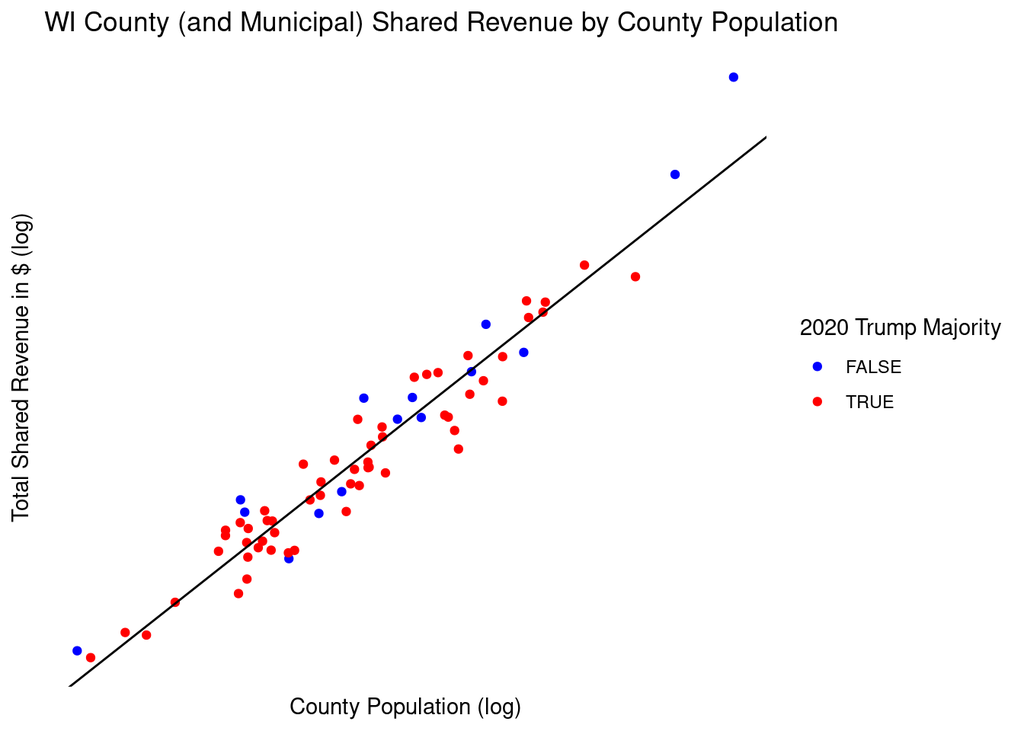

Although *individuals* are given roughly equal shared revenue allocations regardless of where they live, this can result in local governments receiving proportionally less money in shared revenue than their residents pay in taxes. Richer counties tend to receive less than they pay in, and poorer counties more, with total tax revenue serving as a rough proxy for per-capita wealth. The graph below shows the amount of shared revenue counties were allocated above their relative (per capita) contribution through income and sales taxes. This is the amount they were subsidized by tax payers in other counties, with bars going to the left showing a *negative* subsidy. Counties are displayed in descending order by per-capita total tax revenue, showing that poorer counties generally received larger subsidies.[^3] It also shows that there was a great deal of variability in subsidy between counties of similar per-capita tax. County partisanship is also shown, but did not predict subsidy.

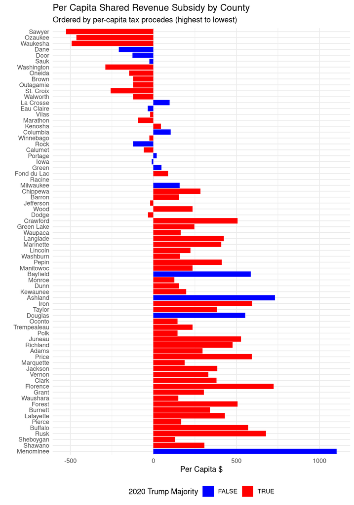

The graph below shows the percentage change in per-capita shared revenue for 2020 if there were no subsidy, meaning that each county received shared revenue proportional to their total tax contribution. Because of the patterns of wealth in Wisconsin, an end (or scaling back) of the shared revenue subsidy would be particular devastating for primarily rural poorer counties and Milwaukee County. However, it would significantly benefit rich (primarily suburban) ones like Dane County and counties in the Milwaukee suburbs.

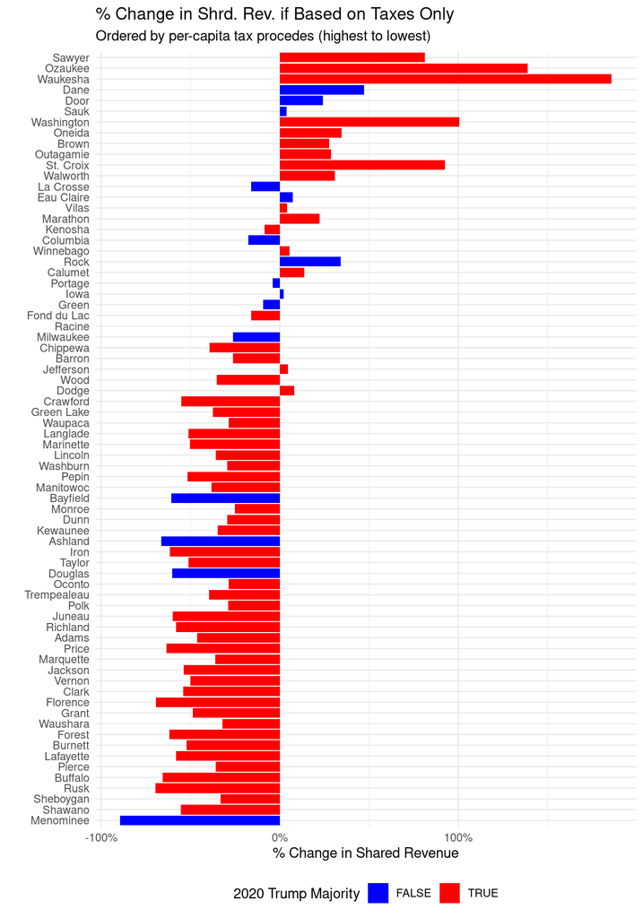

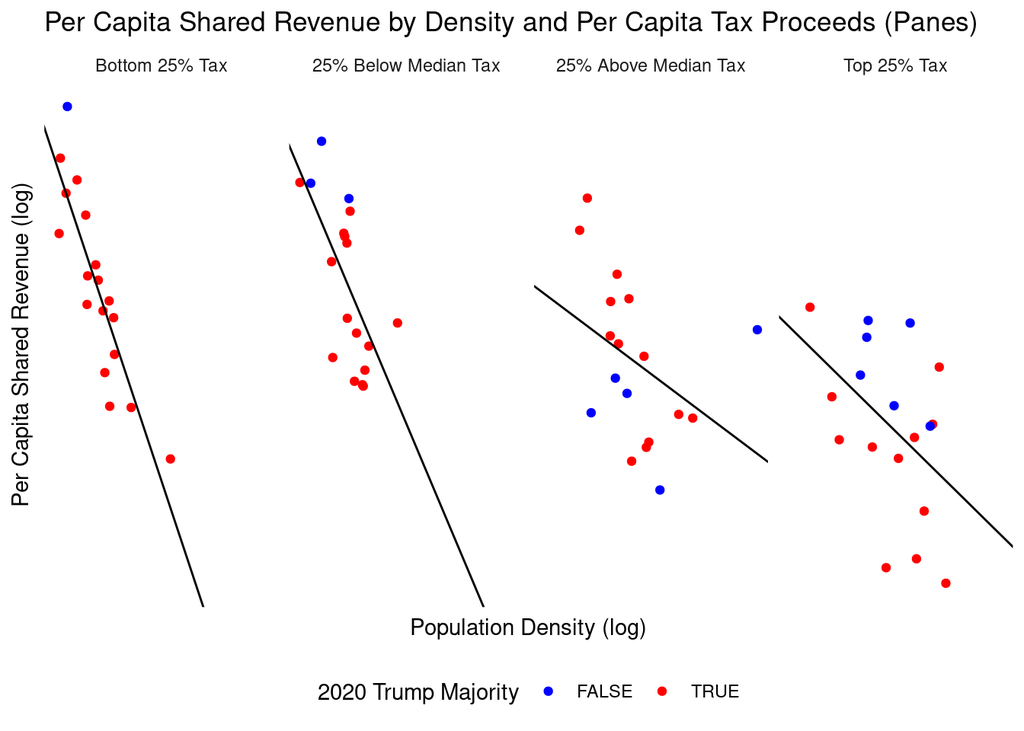

## Is Wisconsin’s Shared Revenue System Fair?

There are strong norms of fairness that require citizens to have equal access to government services regardless of wealth. For instance, most people would consider it unjust for a government to provide different tiers of services based upon the amount an individual pays to the government in taxes. Much the same can be said for providing more shared revenue to some *communities* based upon the higher contribution of their residents to tax revenues. In this respect, the current method, which provides all communities with similar per-capita shared revenue allocations, is fair.

An admittedly more speculative argument might be made to justify higher per-capita shared revenue allocations to less dense areas or areas with large amounts of older infrastructure (like Milwaukee County). Because services are more expensive to provide in these areas, and what matters to people is the quality of services provided rather than how much money it takes to provide them, it may be fairer to provide funds necessary for equality of service quality rather than equal funds. Of course, the more expensive cost to provide services in rural areas may just as easily justify the government in providing incentives to abandon rural communities where jobs are scarce and the provision of services is more expensive.

Even without evaluating these arguments it is easy to see that much of the dominant narrative about shared revenue isn’t based in fact. For instance, the commonly expressed idea that hard-working conservative people in rural and suburban counties subsidize the profligacy of liberals in Madison and Milwaukee is clearly false. Most rural counties are heavily subsidized by tax-payers in more urban ones, including Dane county, and the per-capita subsidy provided to Milwaukee County is much smaller than most rural counties.

Some have also claimed that the shared revenue system is explicitly unfair to more liberal communities, like Madison and Milwaukee. However, the political affiliation of a county doesn’t appear to have any impact on its shared revenue allocation. Dane and Milwaukee counties receive per-capita allocations slightly above what would be expected from their population alone. And although Dane County does have a substantial negative subsidy, so do other suburban counties that are much more conservative.

Certainly any substantial changes to shared revenue allocation - like allocating based upon tax revenues rather than population - would require a deeper discussion of an alternative notion of fairness than the one I describe above. There is a model for this in how local property taxes are largely collected by and allocated to the communities in which the are raised. Perhaps it can be argued that tax payers have a substantial interest in having their income and sales taxes stay in their own communities, where it will impact them more and be easier for them to control (through local government). However, allowing richer communities to keep more taxes of their residents would have a devastating impact on services in poorer communities. Additionally, it seems to ignore existing criticisms of how property taxes are currently kept by the communities in which they are raised, especially how this system leads to under-funding of schools and various social services in poorer communities. It would be odd for liberals to argue for this system’s extension to all forms of taxation.

*All source code and data for this analysis available [here](https://github.com/mjzenz/shared-revenue).*

© 2023 Michael J. Zenz mjzenz.org